# Final Project

Sanyukta Ghai

March 14, 2019

# Clear environment

```r
# Clear environment of variables and functions
rm(list = ls(all = TRUE))
# Clear environmet of packages
if(is.null(sessionInfo()$otherPkgs) == FALSE)lapply(paste("package:", names(sessionInfo()$otherPkgs), sep=""), detach, character.only = TRUE, unload = TRUE)
```

# Load packages

```r
# Load libraries
library(tidyverse) # tidyverse syntax
library(ggplot2) # Neat Graphs
library(kableExtra) # Pretty HTML Tables
library(corrplot) # Pairwise correlation plot
library(GGally)  # For ggpairs, a detailed correlation graphic
library(gridExtra) # Arrange graphs in a grid
library(janitor) # Pretty cross-tabs
```

# Load data

```r
#Load Data
video_games_raw_data <- read.csv("../raw_data/vgsales.csv")

str(video_games_raw_data)
```

```
## 'data.frame':    16598 obs. of  11 variables:
##  $ Rank        : int  1 2 3 4 5 6 7 8 9 10 ...
##  $ Name        : Factor w/ 11493 levels "¡Shin Chan Flipa en colores!",..: 10991 9343 5531 10993 7364 9707 6648 10989 6651 2594 ...
##  $ Platform    : Factor w/ 31 levels "2600","3DO","3DS",..: 26 12 26 26 6 6 5 26 26 12 ...
##  $ Year        : Factor w/ 40 levels "1980","1981",..: 27 6 29 30 17 10 27 27 30 5 ...
##  $ Genre       : Factor w/ 12 levels "Action","Adventure",..: 11 5 7 11 8 6 5 4 5 9 ...
##  $ Publisher   : Factor w/ 579 levels "10TACLE Studios",..: 369 369 369 369 369 369 369 369 369 369 ...
##  $ NA_Sales    : num  41.5 29.1 15.8 15.8 11.3 ...
##  $ EU_Sales    : num  29.02 3.58 12.88 11.01 8.89 ...
##  $ JP_Sales    : num  3.77 6.81 3.79 3.28 10.22 ...
##  $ Other_Sales : num  8.46 0.77 3.31 2.96 1 0.58 2.9 2.85 2.26 0.47 ...
##  $ Global_Sales: num  82.7 40.2 35.8 33 31.4 ...
```

```r
summary(video_games_raw_data)
```

```
##       Rank                                Name          Platform
##  Min.   :    1   Need for Speed: Most Wanted:   12   DS     :2163
##  1st Qu.: 4151   FIFA 14                    :    9   PS2    :2161
##  Median : 8300   LEGO Marvel Super Heroes   :    9   PS3    :1329
##  Mean   : 8301   Madden NFL 07              :    9   Wii    :1325
##  3rd Qu.:12450   Ratatouille                :    9   X360   :1265
##  Max.   :16600   Angry Birds Star Wars      :    8   PSP    :1213
##                  (Other)                    :16542   (Other):7142
##       Year               Genre                             Publisher
##  2009   :1431   Action      :3316   Electronic Arts             : 1351
##  2008   :1428   Sports      :2346   Activision                  :  975
##  2010   :1259   Misc        :1739   Namco Bandai Games          :  932
##  2007   :1202   Role-Playing:1488   Ubisoft                     :  921
##  2011   :1139   Shooter     :1310   Konami Digital Entertainment:  832
##  2006   :1008   Adventure   :1286   THQ                         :  715
##  (Other):9131   (Other)     :5113   (Other)                     :10872
##     NA_Sales          EU_Sales          JP_Sales         Other_Sales
##  Min.   : 0.0000   Min.   : 0.0000   Min.   : 0.00000   Min.   : 0.00000
##  1st Qu.: 0.0000   1st Qu.: 0.0000   1st Qu.: 0.00000   1st Qu.: 0.00000
##  Median : 0.0800   Median : 0.0200   Median : 0.00000   Median : 0.01000
##  Mean   : 0.2647   Mean   : 0.1467   Mean   : 0.07778   Mean   : 0.04806
##  3rd Qu.: 0.2400   3rd Qu.: 0.1100   3rd Qu.: 0.04000   3rd Qu.: 0.04000
##  Max.   :41.4900   Max.   :29.0200   Max.   :10.22000   Max.   :10.57000
##
##   Global_Sales
##  Min.   : 0.0100
##  1st Qu.: 0.0600
##  Median : 0.1700
##  Mean   : 0.5374
##  3rd Qu.: 0.4700
##  Max.   :82.7400
##
```

### Observations

- Table contains 16598 observations of 11 variables
- 5 factor variables - Name, Platform, Year, Genre, Publisher
- 6 numeric variables - Rank, NA_Sales, EU_Sales, JP_Sales, Other_Sales

### Filter data based on our scope

```r
# Years from 2006 onwards
# Remove Rank column
# Consider only US Sales
# Remove rows with 0 sales
# Pick top 200 games
video_games_data <- video_games_raw_data %>%
  select(-c(Rank, EU_Sales, JP_Sales, Other_Sales)) %>%
  filter(Year %in% seq(2006, 2016, by = 1)) %>%
  mutate(Year = Year %>% droplevels()) %>%
  filter(NA_Sales > 0.000) %>%
  filter(!Publisher %in% c("NA", "N/A", "Unknown")) %>%
  top_n(200, NA_Sales) %>%
  mutate(Year = Year %>% droplevels()) %>%
  mutate(Platform = Platform %>% droplevels()) %>%
  mutate(Name = Name %>% droplevels()) %>%
  mutate(Publisher = Publisher %>% droplevels()) %>%
  mutate(Genre = Genre %>% droplevels())

str(video_games_data)
```

```
## 'data.frame':    200 obs. of  7 variables:
##  $ Name        : Factor w/ 157 levels "Animal Crossing: City Folk",..: 153 95 154 111 152 114 150 151 69 53 ...
##  $ Platform    : Factor w/ 11 levels "3DS","DS","PC",..: 8 8 8 2 8 8 8 8 10 5 ...
##  $ Year        : Factor w/ 10 levels "2006","2007",..: 1 3 4 1 1 4 2 4 5 8 ...
##  $ Genre       : Factor w/ 11 levels "Action","Adventure",..: 10 6 10 5 4 5 10 10 4 1 ...
##  $ Publisher   : Factor w/ 22 levels "505 Games","Activision",..: 13 13 13 13 13 13 13 13 10 19 ...
##  $ NA_Sales    : num  41.5 15.8 15.8 11.4 14 ...
##  $ Global_Sales: num  82.7 35.8 33 30 29 ...
```

```r
summary(video_games_data)
```

```
##                                Name        Platform       Year
##  Grand Theft Auto V              :  4   X360   :69   2007   :28
##  Call of Duty: Advanced Warfare  :  3   PS3    :37   2010   :28
##  Call of Duty: Ghosts            :  3   Wii    :33   2009   :26
##  Guitar Hero III: Legends of Rock:  3   DS     :14   2008   :23
##  Assassin's Creed                :  2   XOne   :14   2011   :22
##  Assassin's Creed II             :  2   PS4    : 9   2012   :17
##  (Other)                         :183   (Other):24   (Other):56
##           Genre                     Publisher     NA_Sales
##  Action      :44   Nintendo              :40   Min.   : 1.820
##  Shooter     :44   Activision            :34   1st Qu.: 2.118
##  Sports      :30   Electronic Arts       :27   Median : 2.655
##  Role-Playing:25   Microsoft Game Studios:19   Mean   : 3.798
##  Misc        :23   Take-Two Interactive  :18   3rd Qu.: 3.853
##  Platform    :14   Ubisoft               :17   Max.   :41.490
##  (Other)     :20   (Other)               :45
##   Global_Sales
##  Min.   : 2.090
##  1st Qu.: 3.507
##  Median : 5.050
##  Mean   : 7.295
##  3rd Qu.: 7.728
##  Max.   :82.740
##
```

### Observations

# Questions to be answered

Company A want to know the feasibility of an online game streaming platform similar to ‘Netflix’ for games. They would like to know how to design their initial portfolio on the platform to generate maximum revenue.

- Should Company A tie up with a single publisher or platform?
- Which 3 top performing games should they include in their portfolio
- How should their portfolio split be in terms of game genres

# Functions

```r
# Function to get the relevant grouped data frames
# df -> dataframe
# groupVariable -> the group by column
# output -> the resulting data frame
getGroupedUnivariateData <- function(df, groupVariable) {
  # group_by() store
  # summarise() reduces variable to descriptive stat
  # count is the new variable name, n() is a counting function
  # percent is a new variable, sum() and nrow() are functions
  # tot_sales_units -> total number of units sold per store
  # tot_revenue -> total revenue per store
  # order_by() tot_revenue and tot_sales_units
  result <- df %>%
    group_by_(groupVariable) %>%
    summarise(count = n(),
              percent = (sum(count) / nrow(df)) * 100,
              tot_revenue = sum(NA_Sales),
              avg_revenue = (mean(NA_Sales))) %>%
    arrange(desc(tot_revenue)) %>%
    as.data.frame()

  return(result)
}

# Function to draw histograms using grid.arrange so can see all quant variables together group by variable x
# df -> dataframe
# x -> the group by column
getGroupedUnivariateHistograms <- function(df, x, flip = TRUE) {
  grid.arrange(
    df %>%
      ggplot(aes(x = get(x), y = count)) +
        geom_bar(stat = "identity") +
        {if(flip)coord_flip()} +
        xlab(x),
    df %>%
      ggplot(aes(x = get(x), y = tot_revenue)) +
        geom_bar(stat = "identity") +
        {if(flip)coord_flip()} +
        xlab(x),
    df %>%
      ggplot(aes(x = get(x), y = avg_revenue)) +
        geom_bar(stat = "identity") +
        {if(flip)coord_flip()} +
        xlab(x),
    ncol = 2
  )
}

# Function to draw multivariate graphs
# df -> dataframe
# groupVariable1, groupVariable2 -> the group by columns
# output -> no output -> draws the required graph
getMultivariateGraphical <- function(df, groupVariable1, groupVariable2, flipLabel){
  df %>%
    group_by_(groupVariable1, groupVariable2) %>%
    summarise(count = n()) %>%
    ggplot(aes(get(groupVariable1), get(groupVariable2))) +
    coord_flip() +
    geom_tile(aes(fill = -count)) +
    xlab(groupVariable1) +
    ylab(groupVariable2) +
    {if(flipLabel)theme(axis.text.x = element_text(angle = 45))}
}
```

# 1. Univariate non-graphical – Categorical

Categorical data - tabulation

### Platform

```r
# Count and revenue by Platform
vg_platform <- getGroupedUnivariateData(video_games_data, "Platform")
vg_platform %>%
  kable() %>%
  kable_styling(bootstrap_options = c("striped", "hover")) %>%
  scroll_box(height = "300px")
```

| Platform | count | percent | tot_revenue | avg_revenue |
| --- | --- | --- | --- | --- |
| X360 | 69 | 34.5 | 257.98 | 3.738841 |
| Wii | 33 | 16.5 | 205.72 | 6.233939 |
| PS3 | 37 | 18.5 | 109.28 | 2.953514 |
| DS | 14 | 7.0 | 53.98 | 3.855714 |
| XOne | 14 | 7.0 | 33.79 | 2.413571 |
| 3DS | 8 | 4.0 | 29.97 | 3.746250 |
| PS4 | 9 | 4.5 | 27.03 | 3.003333 |
| PS2 | 7 | 3.5 | 19.12 | 2.731429 |
| WiiU | 5 | 2.5 | 12.70 | 2.540000 |
| PC | 3 | 1.5 | 7.56 | 2.520000 |
| PSP | 1 | 0.5 | 2.45 | 2.450000 |

### Observations

- Top 5 Platforms by Total Revenue are X360, Wii, PS3, DS, XOne
- Maximum number of games on X360(69) and PS3(37)
- X360, Wii and PS3 make up to 70% of the total games

### Year

```r
# Count and revenue by Year
vg_year <- getGroupedUnivariateData(video_games_data, "Year")
vg_year %>%
  kable() %>%
  kable_styling(bootstrap_options = c("striped", "hover")) %>%
  scroll_box(height = "300px")
```

| Year | count | percent | tot_revenue | avg_revenue |
| --- | --- | --- | --- | --- |
| 2010 | 28 | 14.0 | 108.43 | 3.872500 |
| 2009 | 26 | 13.0 | 107.26 | 4.125385 |
| 2006 | 14 | 7.0 | 102.55 | 7.325000 |
| 2007 | 28 | 14.0 | 93.04 | 3.322857 |
| 2008 | 23 | 11.5 | 83.42 | 3.626956 |
| 2011 | 22 | 11.0 | 76.61 | 3.482273 |
| 2012 | 17 | 8.5 | 56.73 | 3.337059 |
| 2013 | 14 | 7.0 | 54.68 | 3.905714 |
| 2014 | 15 | 7.5 | 40.99 | 2.732667 |
| 2015 | 13 | 6.5 | 35.87 | 2.759231 |

### Observations

- Top Years by Revenue are 2010, 2009, 2006
- Maximum number of games launched between 2007 to 2011

### Genre

```r
# Count and revenue by Genre
vg_genre <- getGroupedUnivariateData(video_games_data, "Genre")
vg_genre %>%
  kable() %>%
  kable_styling(bootstrap_options = c("striped", "hover")) %>%
  scroll_box(height = "300px")
```

| Genre | count | percent | tot_revenue | avg_revenue |
| --- | --- | --- | --- | --- |
| Shooter | 44 | 22.0 | 185.38 | 4.213182 |
| Sports | 30 | 15.0 | 137.29 | 4.576333 |
| Action | 44 | 22.0 | 131.06 | 2.978636 |
| Misc | 23 | 11.5 | 97.81 | 4.252609 |
| Role-Playing | 25 | 12.5 | 75.77 | 3.030800 |
| Platform | 14 | 7.0 | 63.13 | 4.509286 |
| Racing | 7 | 3.5 | 34.10 | 4.871429 |
| Fighting | 6 | 3.0 | 18.40 | 3.066667 |
| Adventure | 3 | 1.5 | 7.07 | 2.356667 |
| Simulation | 3 | 1.5 | 7.01 | 2.336667 |
| Strategy | 1 | 0.5 | 2.56 | 2.560000 |

### Publisher

```r
# Count and revenue by Publisher
vg_publisher <- getGroupedUnivariateData(video_games_data, "Publisher")
vg_publisher %>%
  kable() %>%
  kable_styling(bootstrap_options = c("striped", "hover")) %>%
  scroll_box(height = "300px")
```

| Publisher | count | percent | tot_revenue | avg_revenue |
| --- | --- | --- | --- | --- |
| Nintendo | 40 | 20.0 | 242.89 | 6.072250 |
| Activision | 34 | 17.0 | 140.19 | 4.123235 |
| Microsoft Game Studios | 19 | 9.5 | 84.44 | 4.444210 |
| Electronic Arts | 27 | 13.5 | 64.10 | 2.374074 |
| Take-Two Interactive | 18 | 9.0 | 63.60 | 3.533333 |
| Ubisoft | 17 | 8.5 | 51.91 | 3.053529 |
| Sony Computer Entertainment | 12 | 6.0 | 29.49 | 2.457500 |
| Bethesda Softworks | 7 | 3.5 | 20.69 | 2.955714 |
| Warner Bros. Interactive Entertainment | 4 | 2.0 | 9.70 | 2.425000 |
| LucasArts | 3 | 1.5 | 8.40 | 2.800000 |
| Capcom | 4 | 2.0 | 7.91 | 1.977500 |
| 505 Games | 2 | 1.0 | 6.63 | 3.315000 |
| Sega | 2 | 1.0 | 4.47 | 2.235000 |
| Eidos Interactive | 2 | 1.0 | 4.43 | 2.215000 |
| Disney Interactive Studios | 2 | 1.0 | 3.94 | 1.970000 |
| RedOctane | 1 | 0.5 | 3.81 | 3.810000 |
| Konami Digital Entertainment | 1 | 0.5 | 2.63 | 2.630000 |
| Sony Computer Entertainment Europe | 1 | 0.5 | 2.41 | 2.410000 |
| MTV Games | 1 | 0.5 | 2.15 | 2.150000 |
| Mindscape | 1 | 0.5 | 1.97 | 1.970000 |
| THQ | 1 | 0.5 | 1.94 | 1.940000 |
| Square Enix | 1 | 0.5 | 1.88 | 1.880000 |

### Observations

# 2. Univariate graphical – Categorical

Histograms

### Platform

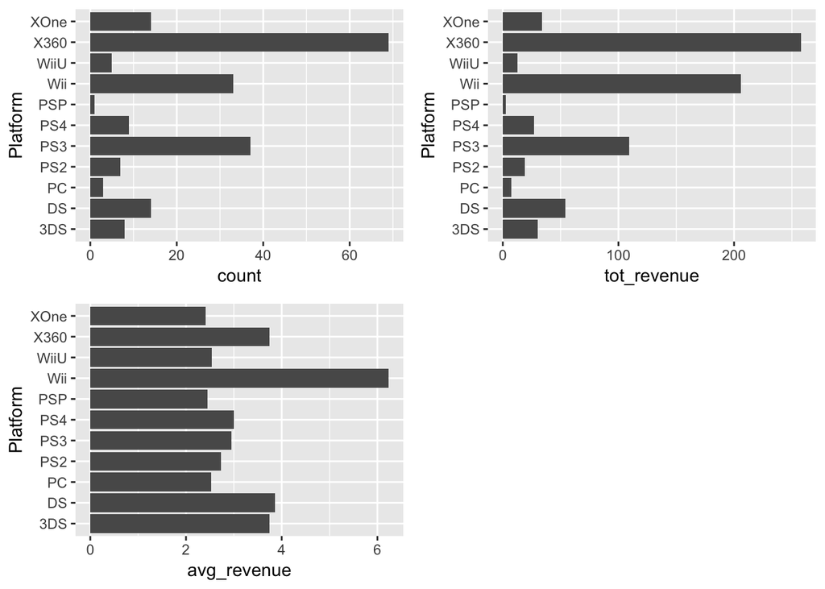

```r
# Revenue by Platform
getGroupedUnivariateHistograms(vg_platform, "Platform")
```

### Observations

- X360 has maximum games
- X360 has maximum total revenue
- Wii has maximum average revenue

### Year

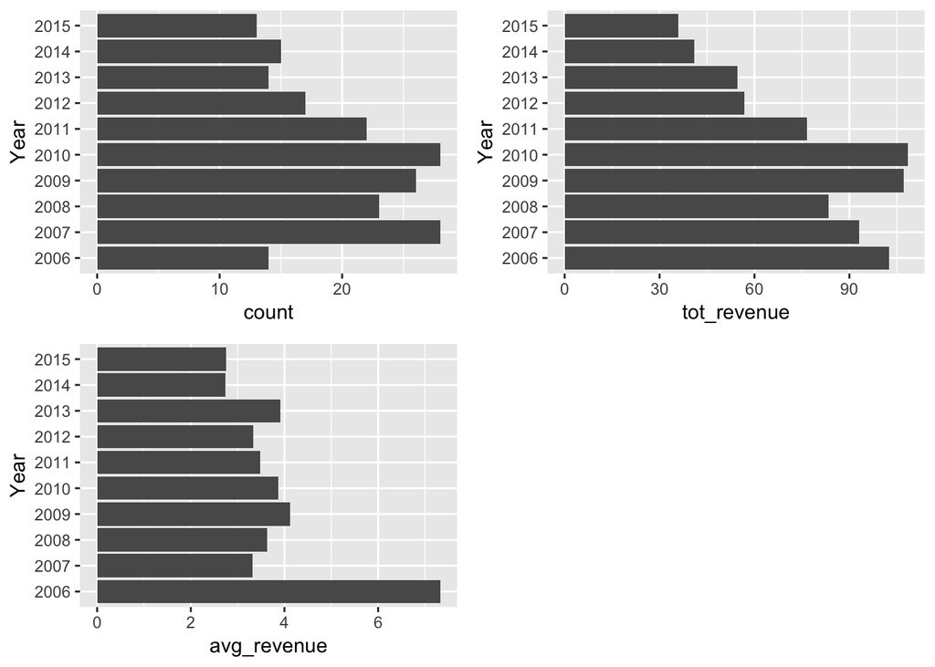

```r
# Revenue by Year
getGroupedUnivariateHistograms(vg_year, "Year")
```

### Observations

- Most games were released between 2006 to 2011 with 2010 being maximum
- Total Revenue is maximum in year 2010
- Maximum average revenue was in 2006

### Genre

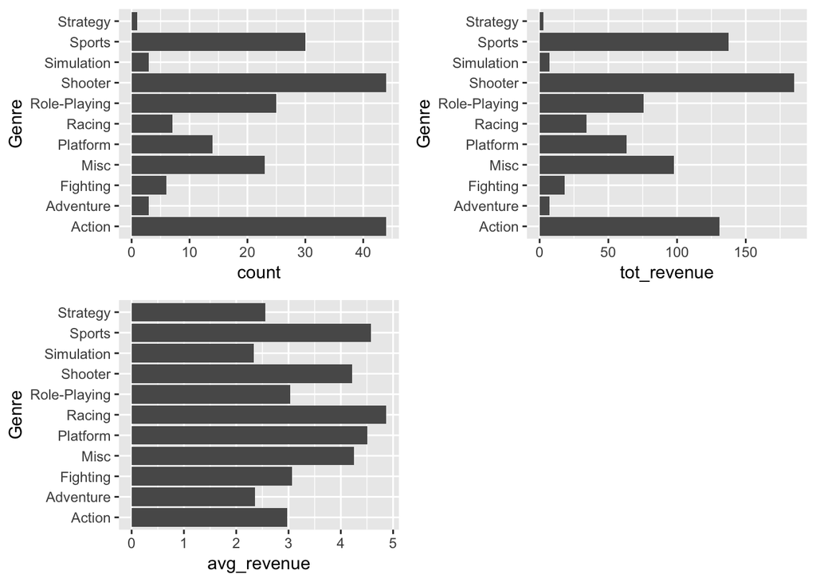

```r
# Revenue by Genre
getGroupedUnivariateHistograms(vg_genre, "Genre")
```

### Observations

- Action & Shooter Genre have the most number of games
- Shooter Genre has maximum total revenue
- Racing Genre has maximum average revenue

### Publisher

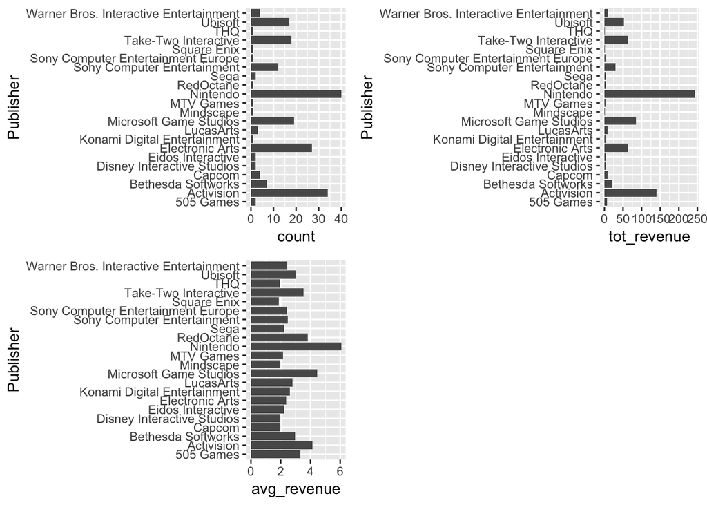

```r
# Revenue by Publisher
getGroupedUnivariateHistograms(vg_publisher, "Publisher")
```

### Observations

- Nintendo followed by Activision in total games and revenue
- Nintendo followed by Microsoft Game Studios in average revenue

# 3. Univariate non-graphical – Quantitative

Descriptive Statistics

```r
# Get descriptive stats
summary(video_games_data)
```

```
##                                Name        Platform       Year
##  Grand Theft Auto V              :  4   X360   :69   2007   :28
##  Call of Duty: Advanced Warfare  :  3   PS3    :37   2010   :28
##  Call of Duty: Ghosts            :  3   Wii    :33   2009   :26
##  Guitar Hero III: Legends of Rock:  3   DS     :14   2008   :23
##  Assassin's Creed                :  2   XOne   :14   2011   :22
##  Assassin's Creed II             :  2   PS4    : 9   2012   :17
##  (Other)                         :183   (Other):24   (Other):56
##           Genre                     Publisher     NA_Sales
##  Action      :44   Nintendo              :40   Min.   : 1.820
##  Shooter     :44   Activision            :34   1st Qu.: 2.118
##  Sports      :30   Electronic Arts       :27   Median : 2.655
##  Role-Playing:25   Microsoft Game Studios:19   Mean   : 3.798
##  Misc        :23   Take-Two Interactive  :18   3rd Qu.: 3.853
##  Platform    :14   Ubisoft               :17   Max.   :41.490
##  (Other)     :20   (Other)               :45
##   Global_Sales
##  Min.   : 2.090
##  1st Qu.: 3.507
##  Median : 5.050
##  Mean   : 7.295
##  3rd Qu.: 7.728
##  Max.   :82.740
##
```

### Observations

# 4. Univariate graphical – Quantitative

Histograms

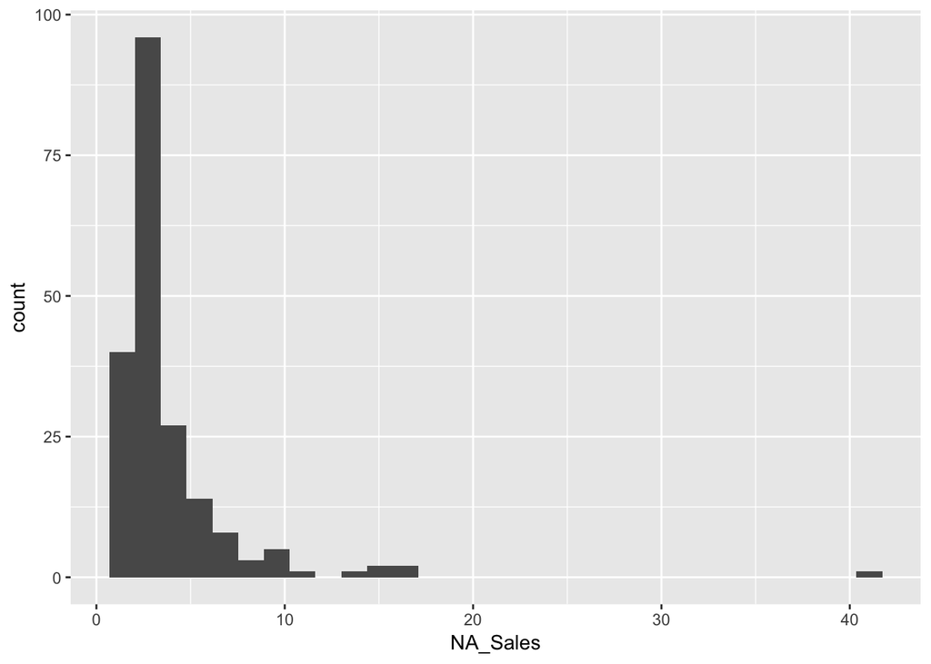

```r
# Code histograms using ggplot()
video_games_data %>%
  ggplot(aes(NA_Sales)) +
  geom_histogram()
```

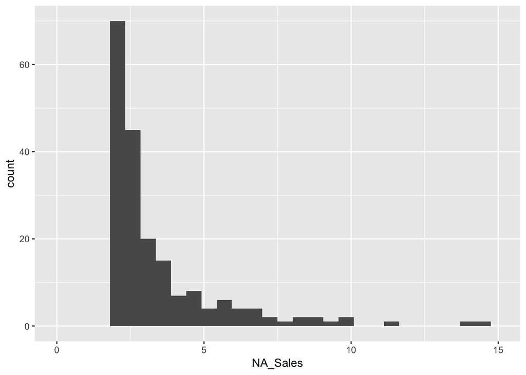

```r
video_games_data %>%
  ggplot(aes(NA_Sales)) +
  geom_histogram() +
  xlim(0,15)
```

### Observations

- Most NA_Sales between 2 to 10 Million Dollars
- Few outliers around 40 Million Dollars

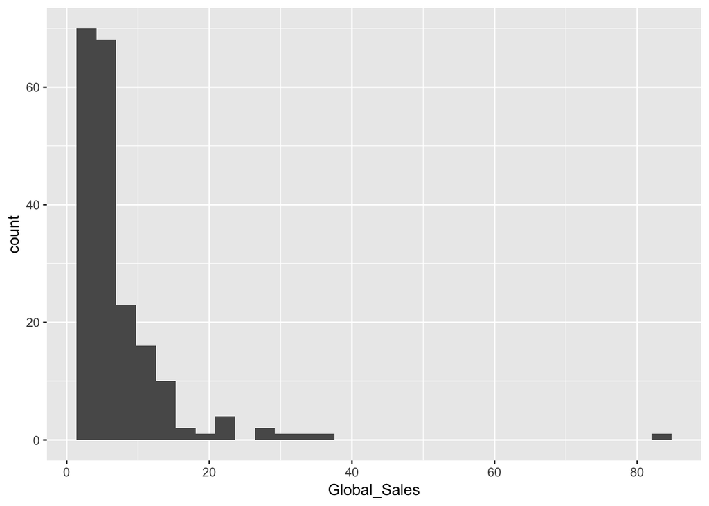

```r
# Code histograms using ggplot()
video_games_data %>%
  ggplot(aes(Global_Sales)) +
  geom_histogram()
```

### Observations

- Most Global_Sales between 2 to 40 Million Dollars
- Few outliers around 82 Million Dollars

Boxplots

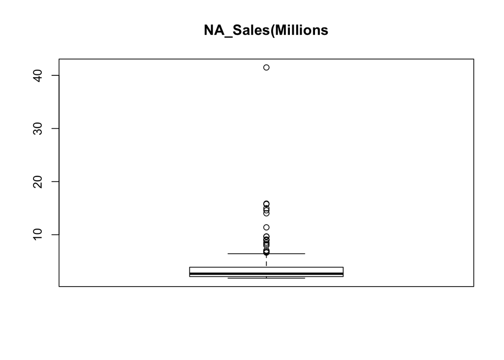

```r
# Code boxplot
boxplot(video_games_data$NA_Sales, main = "NA_Sales(Millions")
```

### Observations same as histograms

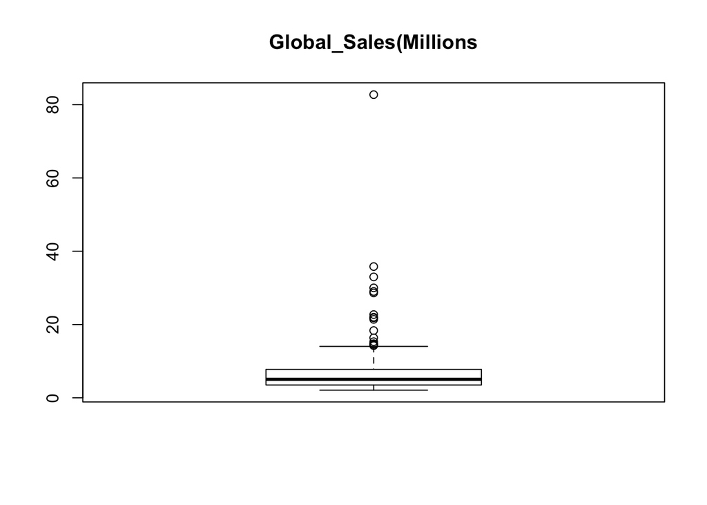

```r
# Code boxplot
boxplot(video_games_data$Global_Sales, main = "Global_Sales(Millions")
```

### Observations

- Most Global_Sales between 2 to 15 Million Dollars
- Few outliers from 15 to 82 Million Dollars

# 5. Multivariate non-graphical – Categorical

Cross-Tabs

```r
# Make cross-tabs between two categorical variables using janitor package
video_games_data %>%
  tabyl(Platform, Publisher) %>%
  adorn_totals(where = c("row", "col")) %>%
  kable() %>%
  kable_styling(bootstrap_options = c("striped", "hover"))# %>%
```

| Platform | 505 Games | Activision | Bethesda Softworks | Capcom | Disney Interactive Studios | Eidos Interactive | Electronic Arts | Konami Digital Entertainment | LucasArts | Microsoft Game Studios | Mindscape | MTV Games | Nintendo | RedOctane | Sega | Sony Computer Entertainment | Sony Computer Entertainment Europe | Square Enix | Take-Two Interactive | THQ | Ubisoft | Warner Bros. Interactive Entertainment | Total |
| --- | --- | --- | --- | --- | --- | --- | --- | --- | --- | --- | --- | --- | --- | --- | --- | --- | --- | --- | --- | --- | --- | --- | --- |
| 3DS | 0 | 0 | 0 | 0 | 0 | 0 | 0 | 0 | 0 | 0 | 0 | 0 | 8 | 0 | 0 | 0 | 0 | 0 | 0 | 0 | 0 | 0 | 8 |
| DS | 1 | 1 | 0 | 0 | 1 | 0 | 0 | 0 | 1 | 0 | 0 | 0 | 10 | 0 | 0 | 0 | 0 | 0 | 0 | 0 | 0 | 0 | 14 |
| PC | 0 | 3 | 0 | 0 | 0 | 0 | 0 | 0 | 0 | 0 | 0 | 0 | 0 | 0 | 0 | 0 | 0 | 0 | 0 | 0 | 0 | 0 | 3 |
| PS2 | 0 | 1 | 0 | 0 | 0 | 0 | 2 | 0 | 1 | 0 | 0 | 0 | 0 | 1 | 0 | 1 | 0 | 1 | 0 | 0 | 0 | 0 | 7 |
| PS3 | 0 | 7 | 2 | 2 | 0 | 1 | 5 | 1 | 0 | 0 | 0 | 0 | 0 | 0 | 0 | 9 | 1 | 0 | 3 | 0 | 4 | 2 | 37 |
| PS4 | 0 | 3 | 1 | 0 | 0 | 0 | 2 | 0 | 0 | 0 | 0 | 0 | 0 | 0 | 0 | 1 | 0 | 0 | 2 | 0 | 0 | 0 | 9 |
| PSP | 0 | 0 | 0 | 0 | 0 | 0 | 0 | 0 | 0 | 0 | 0 | 0 | 0 | 0 | 0 | 1 | 0 | 0 | 0 | 0 | 0 | 0 | 1 |
| Wii | 1 | 2 | 0 | 0 | 1 | 0 | 1 | 0 | 1 | 0 | 1 | 0 | 17 | 0 | 2 | 0 | 0 | 0 | 1 | 0 | 6 | 0 | 33 |
| WiiU | 0 | 0 | 0 | 0 | 0 | 0 | 0 | 0 | 0 | 0 | 0 | 0 | 5 | 0 | 0 | 0 | 0 | 0 | 0 | 0 | 0 | 0 | 5 |
| X360 | 0 | 13 | 3 | 2 | 0 | 1 | 14 | 0 | 0 | 16 | 0 | 1 | 0 | 0 | 0 | 0 | 0 | 0 | 10 | 1 | 6 | 2 | 69 |
| XOne | 0 | 4 | 1 | 0 | 0 | 0 | 3 | 0 | 0 | 3 | 0 | 0 | 0 | 0 | 0 | 0 | 0 | 0 | 2 | 0 | 1 | 0 | 14 |
| Total | 2 | 34 | 7 | 4 | 2 | 2 | 27 | 1 | 3 | 19 | 1 | 1 | 40 | 1 | 2 | 12 | 1 | 1 | 18 | 1 | 17 | 4 | 200 |

```r
  #scroll_box(height = "300px")
```

### Observations

```r
video_games_data %>%
  tabyl(Publisher, Genre) %>%
  adorn_totals(where = c("row", "col")) %>%
  kable() %>%
  kable_styling(bootstrap_options = c("striped", "hover")) #%>%
```

| Publisher | Action | Adventure | Fighting | Misc | Platform | Racing | Role-Playing | Shooter | Simulation | Sports | Strategy | Total |
| --- | --- | --- | --- | --- | --- | --- | --- | --- | --- | --- | --- | --- |
| 505 Games | 0 | 0 | 0 | 0 | 0 | 0 | 0 | 0 | 1 | 1 | 0 | 2 |
| Activision | 2 | 0 | 0 | 6 | 0 | 0 | 3 | 22 | 0 | 0 | 1 | 34 |
| Bethesda Softworks | 0 | 0 | 0 | 0 | 0 | 0 | 7 | 0 | 0 | 0 | 0 | 7 |
| Capcom | 2 | 0 | 2 | 0 | 0 | 0 | 0 | 0 | 0 | 0 | 0 | 4 |
| Disney Interactive Studios | 0 | 1 | 0 | 0 | 1 | 0 | 0 | 0 | 0 | 0 | 0 | 2 |
| Eidos Interactive | 2 | 0 | 0 | 0 | 0 | 0 | 0 | 0 | 0 | 0 | 0 | 2 |
| Electronic Arts | 0 | 0 | 0 | 0 | 0 | 0 | 2 | 9 | 0 | 16 | 0 | 27 |
| Konami Digital Entertainment | 1 | 0 | 0 | 0 | 0 | 0 | 0 | 0 | 0 | 0 | 0 | 1 |
| LucasArts | 3 | 0 | 0 | 0 | 0 | 0 | 0 | 0 | 0 | 0 | 0 | 3 |
| Microsoft Game Studios | 0 | 0 | 0 | 2 | 0 | 3 | 3 | 10 | 0 | 1 | 0 | 19 |
| Mindscape | 0 | 0 | 0 | 1 | 0 | 0 | 0 | 0 | 0 | 0 | 0 | 1 |
| MTV Games | 0 | 0 | 0 | 1 | 0 | 0 | 0 | 0 | 0 | 0 | 0 | 1 |
| Nintendo | 5 | 0 | 3 | 4 | 10 | 3 | 8 | 1 | 2 | 4 | 0 | 40 |
| RedOctane | 0 | 0 | 0 | 1 | 0 | 0 | 0 | 0 | 0 | 0 | 0 | 1 |
| Sega | 0 | 0 | 0 | 0 | 0 | 0 | 0 | 0 | 0 | 2 | 0 | 2 |
| Sony Computer Entertainment | 6 | 0 | 0 | 1 | 3 | 1 | 0 | 0 | 0 | 1 | 0 | 12 |
| Sony Computer Entertainment Europe | 1 | 0 | 0 | 0 | 0 | 0 | 0 | 0 | 0 | 0 | 0 | 1 |
| Square Enix | 0 | 0 | 0 | 0 | 0 | 0 | 1 | 0 | 0 | 0 | 0 | 1 |
| Take-Two Interactive | 9 | 0 | 0 | 1 | 0 | 0 | 1 | 2 | 0 | 5 | 0 | 18 |
| THQ | 1 | 0 | 0 | 0 | 0 | 0 | 0 | 0 | 0 | 0 | 0 | 1 |
| Ubisoft | 9 | 2 | 0 | 6 | 0 | 0 | 0 | 0 | 0 | 0 | 0 | 17 |
| Warner Bros. Interactive Entertainment | 3 | 0 | 1 | 0 | 0 | 0 | 0 | 0 | 0 | 0 | 0 | 4 |
| Total | 44 | 3 | 6 | 23 | 14 | 7 | 25 | 44 | 3 | 30 | 1 | 200 |

```r
  #scroll_box(height = "300px")
```

### Observations

- Activision has the most shooter games (22)
- Take-Two Interactive and Ubisoft have the most action games (9)
- Electronic Arts have the most Sports games (16)

```r
video_games_data %>%
  tabyl(Genre, Platform) %>%
  adorn_totals(where = c("row", "col")) %>%
  kable() %>%
  kable_styling(bootstrap_options = c("striped", "hover")) #%>%
```

| Genre | 3DS | DS | PC | PS2 | PS3 | PS4 | PSP | Wii | WiiU | X360 | XOne | Total |
| --- | --- | --- | --- | --- | --- | --- | --- | --- | --- | --- | --- | --- |
| Action | 1 | 3 | 0 | 2 | 15 | 2 | 0 | 3 | 0 | 16 | 2 | 44 |
| Adventure | 0 | 1 | 0 | 0 | 1 | 0 | 0 | 0 | 0 | 1 | 0 | 3 |
| Fighting | 1 | 0 | 0 | 0 | 2 | 0 | 0 | 1 | 1 | 1 | 0 | 6 |
| Misc | 0 | 2 | 0 | 2 | 1 | 0 | 0 | 12 | 1 | 5 | 0 | 23 |
| Platform | 2 | 1 | 0 | 0 | 2 | 0 | 1 | 6 | 2 | 0 | 0 | 14 |
| Racing | 1 | 0 | 0 | 0 | 1 | 0 | 0 | 1 | 1 | 3 | 0 | 7 |
| Role-Playing | 2 | 6 | 2 | 1 | 2 | 1 | 0 | 0 | 0 | 10 | 1 | 25 |
| Shooter | 0 | 0 | 0 | 0 | 8 | 4 | 0 | 1 | 0 | 22 | 9 | 44 |
| Simulation | 1 | 1 | 0 | 0 | 0 | 0 | 0 | 1 | 0 | 0 | 0 | 3 |
| Sports | 0 | 0 | 0 | 2 | 5 | 2 | 0 | 8 | 0 | 11 | 2 | 30 |
| Strategy | 0 | 0 | 1 | 0 | 0 | 0 | 0 | 0 | 0 | 0 | 0 | 1 |
| Total | 8 | 14 | 3 | 7 | 37 | 9 | 1 | 33 | 5 | 69 | 14 | 200 |

```r
  #scroll_box(height = "300px")
```

### Observations

- X360 has the most shooter games (22)
- X360 and PS3 have the most action games (16, 15)
- X360 has the most Sports games (11)

Proportion Cross-Tabs

```r
# Make cross-tabs between two categorical variables using janitor package
video_games_data %>%
  tabyl(Platform, Publisher) %>%
  adorn_totals(where = c("row", "col")) %>%
  adorn_percentages() %>%
  adorn_pct_formatting() %>%
  kable() %>%
  kable_styling(bootstrap_options = c("striped", "hover"))# %>%
```

| Platform | 505 Games | Activision | Bethesda Softworks | Capcom | Disney Interactive Studios | Eidos Interactive | Electronic Arts | Konami Digital Entertainment | LucasArts | Microsoft Game Studios | Mindscape | MTV Games | Nintendo | RedOctane | Sega | Sony Computer Entertainment | Sony Computer Entertainment Europe | Square Enix | Take-Two Interactive | THQ | Ubisoft | Warner Bros. Interactive Entertainment | Total |
| --- | --- | --- | --- | --- | --- | --- | --- | --- | --- | --- | --- | --- | --- | --- | --- | --- | --- | --- | --- | --- | --- | --- | --- |
| 3DS | 0.0% | 0.0% | 0.0% | 0.0% | 0.0% | 0.0% | 0.0% | 0.0% | 0.0% | 0.0% | 0.0% | 0.0% | 100.0% | 0.0% | 0.0% | 0.0% | 0.0% | 0.0% | 0.0% | 0.0% | 0.0% | 0.0% | 100.0% |
| DS | 7.1% | 7.1% | 0.0% | 0.0% | 7.1% | 0.0% | 0.0% | 0.0% | 7.1% | 0.0% | 0.0% | 0.0% | 71.4% | 0.0% | 0.0% | 0.0% | 0.0% | 0.0% | 0.0% | 0.0% | 0.0% | 0.0% | 100.0% |
| PC | 0.0% | 100.0% | 0.0% | 0.0% | 0.0% | 0.0% | 0.0% | 0.0% | 0.0% | 0.0% | 0.0% | 0.0% | 0.0% | 0.0% | 0.0% | 0.0% | 0.0% | 0.0% | 0.0% | 0.0% | 0.0% | 0.0% | 100.0% |
| PS2 | 0.0% | 14.3% | 0.0% | 0.0% | 0.0% | 0.0% | 28.6% | 0.0% | 14.3% | 0.0% | 0.0% | 0.0% | 0.0% | 14.3% | 0.0% | 14.3% | 0.0% | 14.3% | 0.0% | 0.0% | 0.0% | 0.0% | 100.0% |
| PS3 | 0.0% | 18.9% | 5.4% | 5.4% | 0.0% | 2.7% | 13.5% | 2.7% | 0.0% | 0.0% | 0.0% | 0.0% | 0.0% | 0.0% | 0.0% | 24.3% | 2.7% | 0.0% | 8.1% | 0.0% | 10.8% | 5.4% | 100.0% |
| PS4 | 0.0% | 33.3% | 11.1% | 0.0% | 0.0% | 0.0% | 22.2% | 0.0% | 0.0% | 0.0% | 0.0% | 0.0% | 0.0% | 0.0% | 0.0% | 11.1% | 0.0% | 0.0% | 22.2% | 0.0% | 0.0% | 0.0% | 100.0% |
| PSP | 0.0% | 0.0% | 0.0% | 0.0% | 0.0% | 0.0% | 0.0% | 0.0% | 0.0% | 0.0% | 0.0% | 0.0% | 0.0% | 0.0% | 0.0% | 100.0% | 0.0% | 0.0% | 0.0% | 0.0% | 0.0% | 0.0% | 100.0% |
| Wii | 3.0% | 6.1% | 0.0% | 0.0% | 3.0% | 0.0% | 3.0% | 0.0% | 3.0% | 0.0% | 3.0% | 0.0% | 51.5% | 0.0% | 6.1% | 0.0% | 0.0% | 0.0% | 3.0% | 0.0% | 18.2% | 0.0% | 100.0% |
| WiiU | 0.0% | 0.0% | 0.0% | 0.0% | 0.0% | 0.0% | 0.0% | 0.0% | 0.0% | 0.0% | 0.0% | 0.0% | 100.0% | 0.0% | 0.0% | 0.0% | 0.0% | 0.0% | 0.0% | 0.0% | 0.0% | 0.0% | 100.0% |
| X360 | 0.0% | 18.8% | 4.3% | 2.9% | 0.0% | 1.4% | 20.3% | 0.0% | 0.0% | 23.2% | 0.0% | 1.4% | 0.0% | 0.0% | 0.0% | 0.0% | 0.0% | 0.0% | 14.5% | 1.4% | 8.7% | 2.9% | 100.0% |
| XOne | 0.0% | 28.6% | 7.1% | 0.0% | 0.0% | 0.0% | 21.4% | 0.0% | 0.0% | 21.4% | 0.0% | 0.0% | 0.0% | 0.0% | 0.0% | 0.0% | 0.0% | 0.0% | 14.3% | 0.0% | 7.1% | 0.0% | 100.0% |
| Total | 1.0% | 17.0% | 3.5% | 2.0% | 1.0% | 1.0% | 13.5% | 0.5% | 1.5% | 9.5% | 0.5% | 0.5% | 20.0% | 0.5% | 1.0% | 6.0% | 0.5% | 0.5% | 9.0% | 0.5% | 8.5% | 2.0% | 100.0% |

```r
  #scroll_box(height = "300px")
```

### Observations

- Activision in the only Publisher for PC
- Sony Computer Entertainment is the only publisher for PSP
- Nintendo is the only publisher for WiiU

```r
video_games_data %>%
  tabyl(Publisher, Genre) %>%
  adorn_totals(where = c("row", "col")) %>%
  adorn_percentages() %>%
  adorn_pct_formatting() %>%
  kable() %>%
  kable_styling(bootstrap_options = c("striped", "hover")) #%>%
```

| Publisher | Action | Adventure | Fighting | Misc | Platform | Racing | Role-Playing | Shooter | Simulation | Sports | Strategy | Total |
| --- | --- | --- | --- | --- | --- | --- | --- | --- | --- | --- | --- | --- |
| 505 Games | 0.0% | 0.0% | 0.0% | 0.0% | 0.0% | 0.0% | 0.0% | 0.0% | 50.0% | 50.0% | 0.0% | 100.0% |
| Activision | 5.9% | 0.0% | 0.0% | 17.6% | 0.0% | 0.0% | 8.8% | 64.7% | 0.0% | 0.0% | 2.9% | 100.0% |
| Bethesda Softworks | 0.0% | 0.0% | 0.0% | 0.0% | 0.0% | 0.0% | 100.0% | 0.0% | 0.0% | 0.0% | 0.0% | 100.0% |
| Capcom | 50.0% | 0.0% | 50.0% | 0.0% | 0.0% | 0.0% | 0.0% | 0.0% | 0.0% | 0.0% | 0.0% | 100.0% |
| Disney Interactive Studios | 0.0% | 50.0% | 0.0% | 0.0% | 50.0% | 0.0% | 0.0% | 0.0% | 0.0% | 0.0% | 0.0% | 100.0% |
| Eidos Interactive | 100.0% | 0.0% | 0.0% | 0.0% | 0.0% | 0.0% | 0.0% | 0.0% | 0.0% | 0.0% | 0.0% | 100.0% |
| Electronic Arts | 0.0% | 0.0% | 0.0% | 0.0% | 0.0% | 0.0% | 7.4% | 33.3% | 0.0% | 59.3% | 0.0% | 100.0% |
| Konami Digital Entertainment | 100.0% | 0.0% | 0.0% | 0.0% | 0.0% | 0.0% | 0.0% | 0.0% | 0.0% | 0.0% | 0.0% | 100.0% |
| LucasArts | 100.0% | 0.0% | 0.0% | 0.0% | 0.0% | 0.0% | 0.0% | 0.0% | 0.0% | 0.0% | 0.0% | 100.0% |
| Microsoft Game Studios | 0.0% | 0.0% | 0.0% | 10.5% | 0.0% | 15.8% | 15.8% | 52.6% | 0.0% | 5.3% | 0.0% | 100.0% |
| Mindscape | 0.0% | 0.0% | 0.0% | 100.0% | 0.0% | 0.0% | 0.0% | 0.0% | 0.0% | 0.0% | 0.0% | 100.0% |
| MTV Games | 0.0% | 0.0% | 0.0% | 100.0% | 0.0% | 0.0% | 0.0% | 0.0% | 0.0% | 0.0% | 0.0% | 100.0% |
| Nintendo | 12.5% | 0.0% | 7.5% | 10.0% | 25.0% | 7.5% | 20.0% | 2.5% | 5.0% | 10.0% | 0.0% | 100.0% |
| RedOctane | 0.0% | 0.0% | 0.0% | 100.0% | 0.0% | 0.0% | 0.0% | 0.0% | 0.0% | 0.0% | 0.0% | 100.0% |
| Sega | 0.0% | 0.0% | 0.0% | 0.0% | 0.0% | 0.0% | 0.0% | 0.0% | 0.0% | 100.0% | 0.0% | 100.0% |
| Sony Computer Entertainment | 50.0% | 0.0% | 0.0% | 8.3% | 25.0% | 8.3% | 0.0% | 0.0% | 0.0% | 8.3% | 0.0% | 100.0% |
| Sony Computer Entertainment Europe | 100.0% | 0.0% | 0.0% | 0.0% | 0.0% | 0.0% | 0.0% | 0.0% | 0.0% | 0.0% | 0.0% | 100.0% |
| Square Enix | 0.0% | 0.0% | 0.0% | 0.0% | 0.0% | 0.0% | 100.0% | 0.0% | 0.0% | 0.0% | 0.0% | 100.0% |
| Take-Two Interactive | 50.0% | 0.0% | 0.0% | 5.6% | 0.0% | 0.0% | 5.6% | 11.1% | 0.0% | 27.8% | 0.0% | 100.0% |
| THQ | 100.0% | 0.0% | 0.0% | 0.0% | 0.0% | 0.0% | 0.0% | 0.0% | 0.0% | 0.0% | 0.0% | 100.0% |
| Ubisoft | 52.9% | 11.8% | 0.0% | 35.3% | 0.0% | 0.0% | 0.0% | 0.0% | 0.0% | 0.0% | 0.0% | 100.0% |
| Warner Bros. Interactive Entertainment | 75.0% | 0.0% | 25.0% | 0.0% | 0.0% | 0.0% | 0.0% | 0.0% | 0.0% | 0.0% | 0.0% | 100.0% |
| Total | 22.0% | 1.5% | 3.0% | 11.5% | 7.0% | 3.5% | 12.5% | 22.0% | 1.5% | 15.0% | 0.5% | 100.0% |

```r
  #scroll_box(height = "300px")
```

### Observations

- Eidos Interactive, Konami Digital Entertainment, LucasArts, Sony Computer Entertainment Europe, THQ only develop for Action Genre
- Mindscape, MTV Games, RedOctane only develop for Misc genre
- Bethesda Softworks only develops role-playing genre
- Shooter and Action genre have maximum games (22% each)

```r
video_games_data %>%
  tabyl(Genre, Platform) %>%
  adorn_totals(where = c("row", "col")) %>%
  adorn_percentages() %>%
  adorn_pct_formatting() %>%
  kable() %>%
  kable_styling(bootstrap_options = c("striped", "hover")) #%>%
```

| Genre | 3DS | DS | PC | PS2 | PS3 | PS4 | PSP | Wii | WiiU | X360 | XOne | Total |
| --- | --- | --- | --- | --- | --- | --- | --- | --- | --- | --- | --- | --- |
| Action | 2.3% | 6.8% | 0.0% | 4.5% | 34.1% | 4.5% | 0.0% | 6.8% | 0.0% | 36.4% | 4.5% | 100.0% |
| Adventure | 0.0% | 33.3% | 0.0% | 0.0% | 33.3% | 0.0% | 0.0% | 0.0% | 0.0% | 33.3% | 0.0% | 100.0% |
| Fighting | 16.7% | 0.0% | 0.0% | 0.0% | 33.3% | 0.0% | 0.0% | 16.7% | 16.7% | 16.7% | 0.0% | 100.0% |
| Misc | 0.0% | 8.7% | 0.0% | 8.7% | 4.3% | 0.0% | 0.0% | 52.2% | 4.3% | 21.7% | 0.0% | 100.0% |
| Platform | 14.3% | 7.1% | 0.0% | 0.0% | 14.3% | 0.0% | 7.1% | 42.9% | 14.3% | 0.0% | 0.0% | 100.0% |
| Racing | 14.3% | 0.0% | 0.0% | 0.0% | 14.3% | 0.0% | 0.0% | 14.3% | 14.3% | 42.9% | 0.0% | 100.0% |
| Role-Playing | 8.0% | 24.0% | 8.0% | 4.0% | 8.0% | 4.0% | 0.0% | 0.0% | 0.0% | 40.0% | 4.0% | 100.0% |
| Shooter | 0.0% | 0.0% | 0.0% | 0.0% | 18.2% | 9.1% | 0.0% | 2.3% | 0.0% | 50.0% | 20.5% | 100.0% |
| Simulation | 33.3% | 33.3% | 0.0% | 0.0% | 0.0% | 0.0% | 0.0% | 33.3% | 0.0% | 0.0% | 0.0% | 100.0% |
| Sports | 0.0% | 0.0% | 0.0% | 6.7% | 16.7% | 6.7% | 0.0% | 26.7% | 0.0% | 36.7% | 6.7% | 100.0% |
| Strategy | 0.0% | 0.0% | 100.0% | 0.0% | 0.0% | 0.0% | 0.0% | 0.0% | 0.0% | 0.0% | 0.0% | 100.0% |
| Total | 4.0% | 7.0% | 1.5% | 3.5% | 18.5% | 4.5% | 0.5% | 16.5% | 2.5% | 34.5% | 7.0% | 100.0% |

```r
  #scroll_box(height = "300px")
```

### Observations

# 6. Multivariate graphical code – Categorical

Grouped Summary graphs with more than 1 Categorical variables

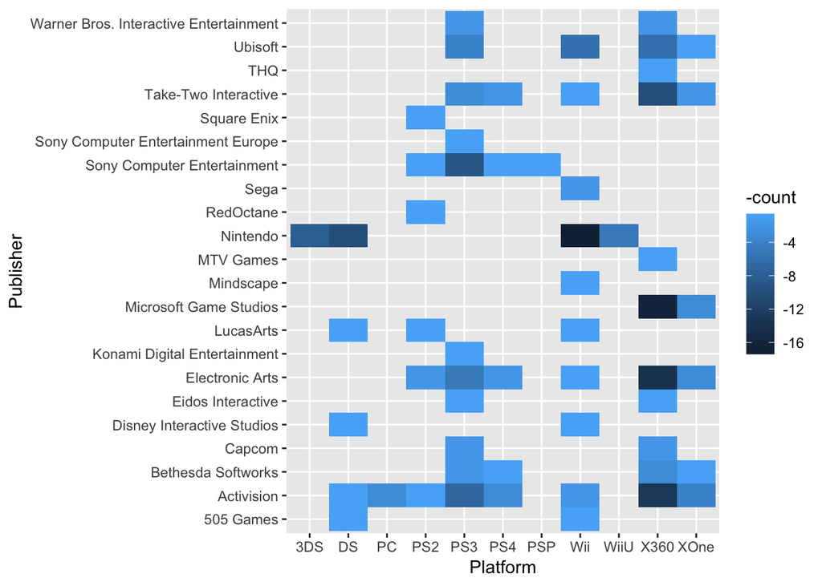

```r
getMultivariateGraphical(video_games_data, "Publisher", "Platform", FALSE)
```

### Observations

- Most publishers developing games for PS3 and X360 Platforms
- Microsoft Game Studios develops exclusively for X360 and XOne
- Sony Computer Entertainment develops exclusively for PS2, PS3, PS4 and PSP
- Nintendo develops exclusively for 3DS, DS, Wii and WiiU
- Activision, Electronic Arts develop for almost all platforms
- Most others develop for PS and X360 platforms
- Need to add more information on platform owners

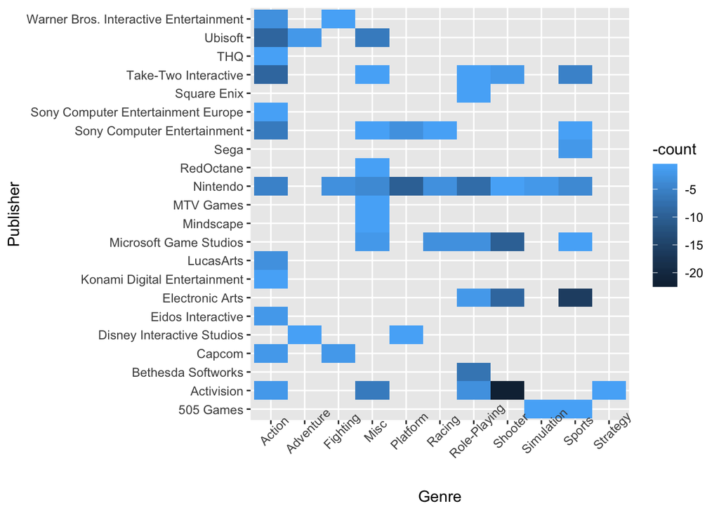

```r
getMultivariateGraphical(video_games_data, "Publisher", "Genre", TRUE)
```

### Observations

- Activision, Microsoft Game Studios and Electronic Arts leading in Shooter games
- Ubisoft, Take-Two Interactive and Sony Computer Entertainment leading in Action games
- Nintendo publishes games across the board except Strategy and Adventure

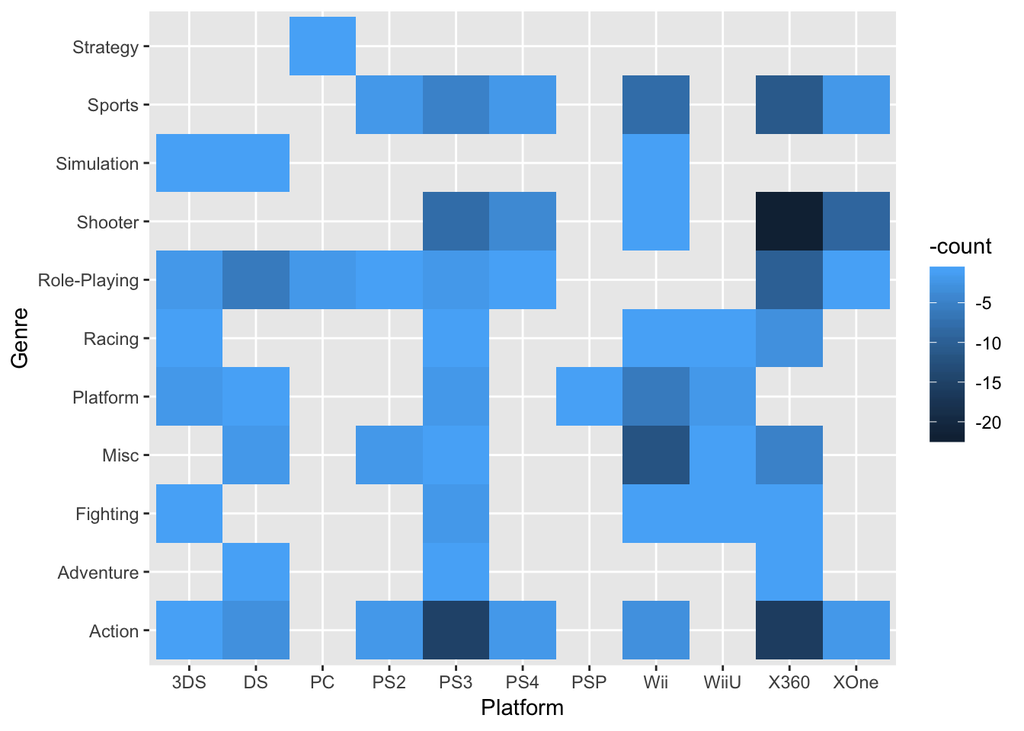

```r
getMultivariateGraphical(video_games_data, "Genre", "Platform", FALSE)
```

### Observations

- Shooter more than Action games on X360 followed by Role-playing and Sports
- Action more than Shooter on PS3 followed by Sports
- Simulation only on 3DS, DS and Wii platforms

# 7. Multivariate non-graphical – Quantitative

Correlation plots

```r
# Find correlation of quantitative variables
cor_plot <- video_games_data %>%
  mutate(Year = as.numeric(Year)) %>%
  select(NA_Sales, Global_Sales, Year)
cor(cor_plot) %>%
  kable() %>%
  kable_styling(bootstrap_options = c("striped","hover"))
```

|  | NA_Sales | Global_Sales | Year |
| --- | --- | --- | --- |
| NA_Sales | 1.0000000 | 0.9656324 | -0.1588179 |
| Global_Sales | 0.9656324 | 1.0000000 | -0.1394479 |
| Year | -0.1588179 | -0.1394479 | 1.0000000 |

### Observations

- NA_Sales and Global_Sales have 96.6% correlation. That means, Global gaming pattern is almost same as North America.
- Year is negatively correlated with both sales showing slow down in game sales.

# 8. Multivariate graphical code – Quantitative

Pairwise Plot

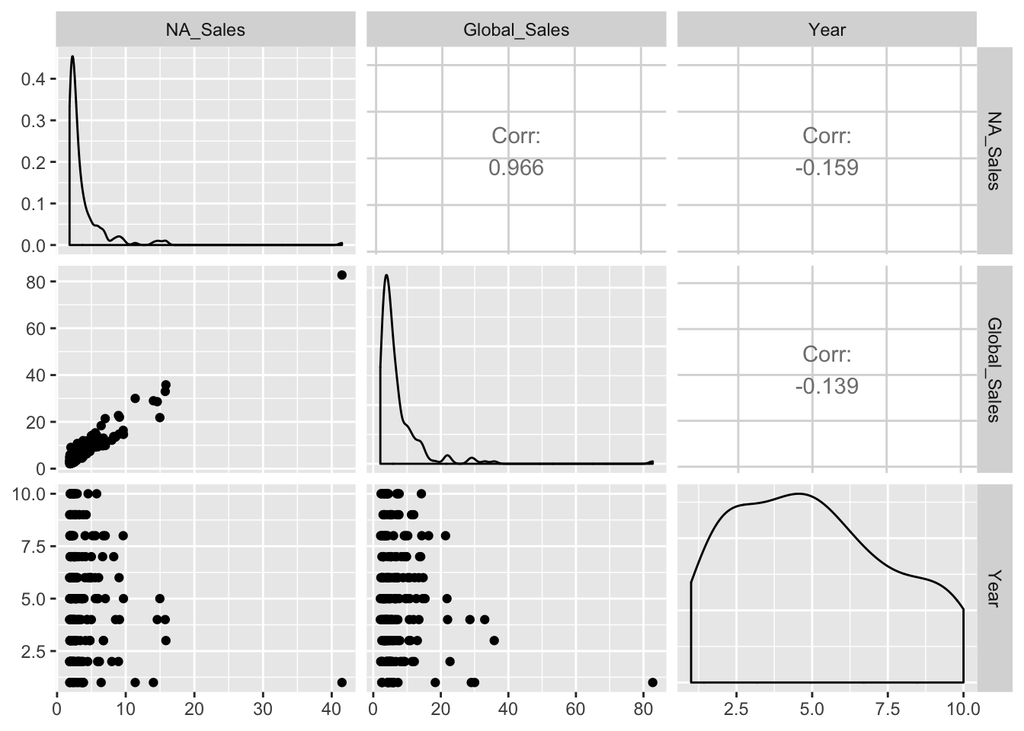

```r
# Correlation plot
pairs_plot <- video_games_data %>%
  mutate(Year = as.numeric(Year)) %>%
  select(NA_Sales, Global_Sales, Year)
pairs_plot %>%
  ggpairs()
```

### Observations

- NA_Sales and Global_Sales have high positive correlation 0.966
- Correlation between Year and NA_Sales is -0.159 and Year and Global_Sales is -0.139. That means North America gaming slowing down faster than Global.

# 9. Multivariate non-graphical – Categorical and Quantitative

matrix tables

```r
video_games_data %>%
  group_by(Genre, Platform) %>%
  summarise(total_revenue = sum(NA_Sales)) %>%
  spread(Platform, total_revenue) %>%
  kable() %>%
  kable_styling()
```

| Genre | 3DS | DS | PC | PS2 | PS3 | PS4 | PSP | Wii | WiiU | X360 | XOne |
| --- | --- | --- | --- | --- | --- | --- | --- | --- | --- | --- | --- |
| Action | 2.03 | 9.19 | NA | 4.17 | 44.63 | 5.76 | NA | 9.63 | NA | 50.73 | 4.92 |
| Adventure | NA | 1.88 | NA | NA | 1.91 | NA | NA | NA | NA | 3.28 | NA |
| Fighting | 3.24 | NA | NA | NA | 4.00 | NA | NA | 6.75 | 2.59 | 1.82 | NA |
| Misc | NA | 6.57 | NA | 7.30 | 1.97 | NA | NA | 51.52 | 2.55 | 27.90 | NA |
| Platform | 8.55 | 11.38 | NA | NA | 4.62 | NA | 2.45 | 31.70 | 4.43 | NA | NA |
| Racing | 4.74 | NA | NA | NA | 2.96 | NA | NA | 15.85 | 3.13 | 7.42 | NA |
| Role-Playing | 9.40 | 21.83 | 5.00 | 1.88 | 4.70 | 2.47 | NA | NA | NA | 28.04 | 2.45 |
| Shooter | NA | NA | NA | NA | 34.26 | 13.99 | NA | 3.06 | NA | 111.65 | 22.42 |
| Simulation | 2.01 | 3.13 | NA | NA | NA | NA | NA | 1.87 | NA | NA | NA |
| Sports | NA | NA | NA | 5.77 | 10.23 | 4.81 | NA | 85.34 | NA | 27.14 | 4.00 |
| Strategy | NA | NA | 2.56 | NA | NA | NA | NA | NA | NA | NA | NA |

### Observations

```r
video_games_data %>%
  group_by(Genre, Publisher) %>%
  summarise(total_revenue = sum(NA_Sales)) %>%
  spread(Genre, total_revenue) %>%
  kable() %>%
  kable_styling()
```

| Publisher | Action | Adventure | Fighting | Misc | Platform | Racing | Role-Playing | Shooter | Simulation | Sports | Strategy |
| --- | --- | --- | --- | --- | --- | --- | --- | --- | --- | --- | --- |
| 505 Games | NA | NA | NA | NA | NA | NA | NA | NA | 3.13 | 3.50 | NA |
| Activision | 4.31 | NA | NA | 16.19 | NA | NA | 7.29 | 109.84 | NA | NA | 2.56 |
| Bethesda Softworks | NA | NA | NA | NA | NA | NA | 20.69 | NA | NA | NA | NA |
| Capcom | 4.07 | NA | 3.84 | NA | NA | NA | NA | NA | NA | NA | NA |
| Disney Interactive Studios | NA | 1.88 | NA | NA | 2.06 | NA | NA | NA | NA | NA | NA |
| Eidos Interactive | 4.43 | NA | NA | NA | NA | NA | NA | NA | NA | NA | NA |
| Electronic Arts | NA | NA | NA | NA | NA | NA | 3.93 | 23.58 | NA | 36.59 | NA |
| Konami Digital Entertainment | 2.63 | NA | NA | NA | NA | NA | NA | NA | NA | NA | NA |
| LucasArts | 8.40 | NA | NA | NA | NA | NA | NA | NA | NA | NA | NA |
| Microsoft Game Studios | NA | NA | NA | 20.55 | NA | 7.42 | 7.93 | 44.62 | NA | 3.92 | NA |
| Mindscape | NA | NA | NA | 1.97 | NA | NA | NA | NA | NA | NA | NA |
| MTV Games | NA | NA | NA | 2.15 | NA | NA | NA | NA | NA | NA | NA |
| Nintendo | 14.30 | NA | 12.58 | 24.85 | 54.00 | 23.72 | 31.23 | 3.06 | 3.88 | 75.27 | NA |
| RedOctane | NA | NA | NA | 3.81 | NA | NA | NA | NA | NA | NA | NA |
| Sega | NA | NA | NA | NA | NA | NA | NA | NA | NA | 4.47 | NA |
| Sony Computer Entertainment | 15.37 | NA | NA | 1.97 | 7.07 | 2.96 | NA | NA | NA | 2.12 | NA |
| Sony Computer Entertainment Europe | 2.41 | NA | NA | NA | NA | NA | NA | NA | NA | NA | NA |
| Square Enix | NA | NA | NA | NA | NA | NA | 1.88 | NA | NA | NA | NA |
| Take-Two Interactive | 42.95 | NA | NA | 2.13 | NA | NA | 2.82 | 4.28 | NA | 11.42 | NA |
| THQ | 1.94 | NA | NA | NA | NA | NA | NA | NA | NA | NA | NA |
| Ubisoft | 22.53 | 5.19 | NA | 24.19 | NA | NA | NA | NA | NA | NA | NA |
| Warner Bros. Interactive Entertainment | 7.72 | NA | 1.98 | NA | NA | NA | NA | NA | NA | NA | NA |

### Observations

- Activision (109.84) has highest total revenues for Shooter games
- Take-Two Interactive (42.95) for Action genre
- Microsoft Game Studios highest revenue is from Shooter games (44.62)
- Nintendo’s revenue is spread out in almost all genres. Highest in sports genre (75.27)

# 10. Multivariate graphical – Categorical and Quantitative

matrix group by and summarize quant graphs

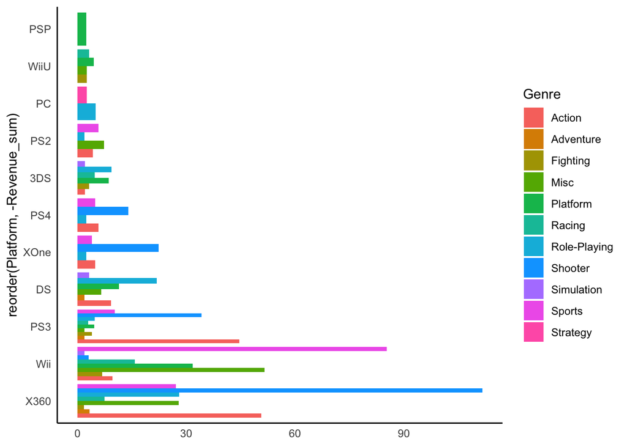

```r
# get total revenue by platform
video_games_data %>%
  group_by(Platform, Genre) %>%
  summarize (Revenue_sum = sum(NA_Sales)) %>%
  ggplot(aes(x = reorder(Platform, -Revenue_sum), y = Revenue_sum, fill = Genre)) +
  geom_bar(stat="identity", position="dodge") +
  coord_flip() +
  theme_classic() +
  theme(axis.ticks.x = element_blank(),
        axis.title.x = element_blank(),
        axis.ticks.y = element_blank())
```

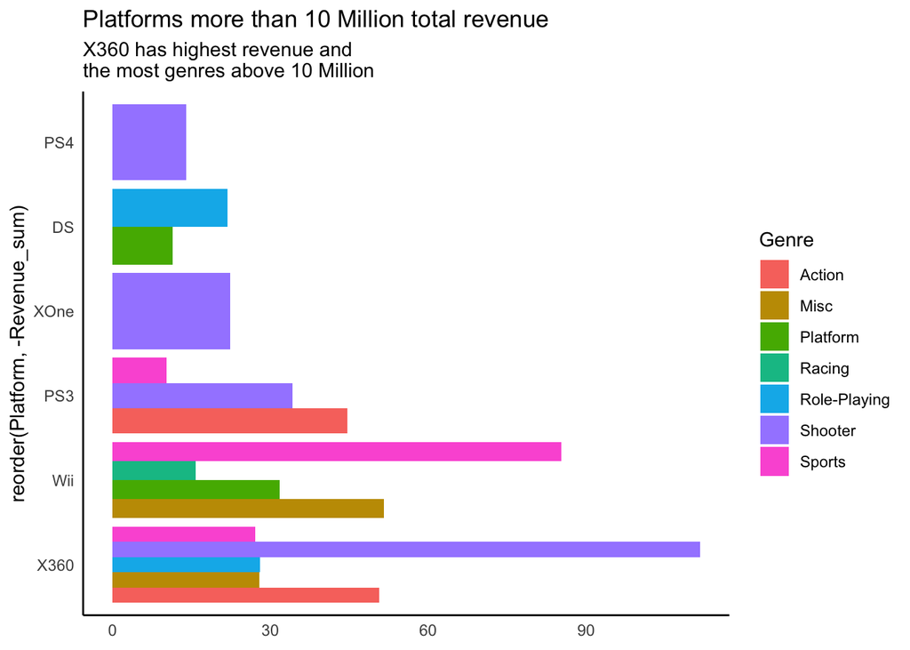

```r
# get total revenue by platform
video_games_data %>%
  group_by(Platform, Genre) %>%
  summarize (Revenue_sum = sum(NA_Sales)) %>%
  filter(Revenue_sum >= 10.0) %>%
  ggplot(aes(x = reorder(Platform, -Revenue_sum), y = Revenue_sum, fill = Genre)) +
  geom_bar(stat="identity", position="dodge") +
  ggtitle("Platforms more than 10 Million total revenue", subtitle = "X360 has highest revenue and \nthe most genres above 10 Million") +
  coord_flip() +
  theme_classic() +
  theme(axis.ticks.x = element_blank(),
        axis.title.x = element_blank(),
        axis.ticks.y = element_blank())
```

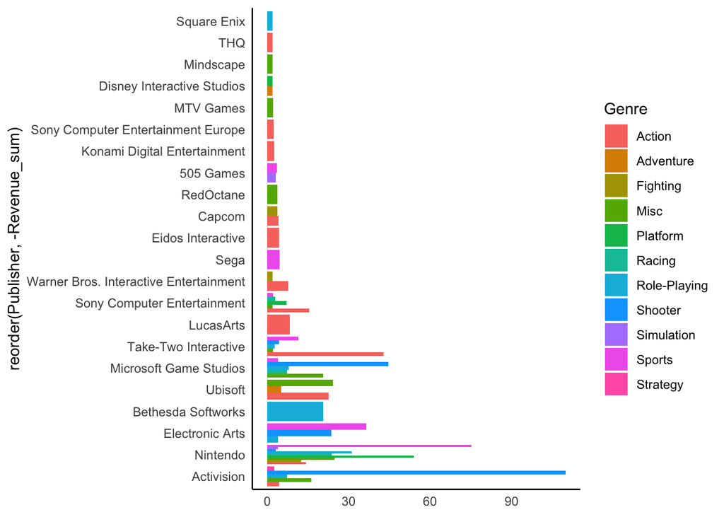

```r
# get total revenue by platform
video_games_data %>%
  group_by(Publisher, Genre) %>%
  summarize (Revenue_sum = sum(NA_Sales)) %>%
  ggplot(aes(x = reorder(Publisher, -Revenue_sum), y = Revenue_sum, fill = Genre)) +
  geom_bar(stat="identity", position="dodge") +
  coord_flip() +
  theme_classic() +
  theme(axis.ticks.x = element_blank(),
        axis.title.x = element_blank(),
        axis.ticks.y = element_blank())
```

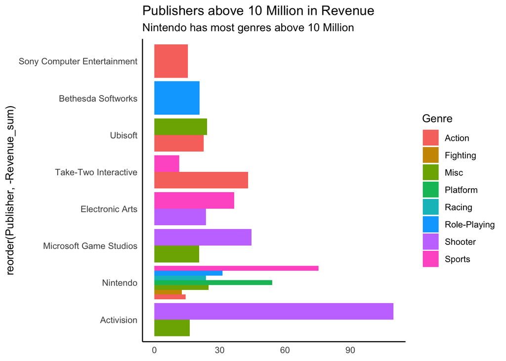

```r
# get total revenue by platform
video_games_data %>%
  group_by(Publisher, Genre) %>%
  summarize (Revenue_sum = sum(NA_Sales)) %>%
  filter(Revenue_sum >= 10.0) %>%
  ggplot(aes(x = reorder(Publisher, -Revenue_sum), y = Revenue_sum, fill = Genre)) +
  geom_bar(stat="identity", position="dodge") +
  ggtitle("Publishers above 10 Million in Revenue", subtitle = "Nintendo has most genres above 10 Million") +
  coord_flip() +
  theme_classic() +
  theme(axis.ticks.x = element_blank(),
        axis.title.x = element_blank(),
        axis.ticks.y = element_blank())
```

# Save Image of file

```r
# Save the rds file to reuse anything from this file in another file
save.image("TA.RData")
# recover using load()
# load("TA.RData")
```